# Lab 1&2: Dylan Maddux and Taylor Kingery

2023-08-30

#**LAB 1**

#**Question 1** my_data <- read.csv(“https://remiller1450.github.io/data/HappyPlanet.csv”)

#**Question 2** my_df <- data.frame(J = seq(from = 0, to = 100, by = 10), K = rep(“XYZ”, times = 11)) print(df)

#**Question 4** my_data [57,3]

#**Question 5 P1** lastThree <- my_data [141:143,] lastThree

#**Question 5P2** lastTen <- my_data [134:143,] lastTen ?median median(lastTen$LifeExpectancy)2

#**Question 6**: my_data[my_data$Country == “Albania”, ] This code works because it takes only the values from the row “Albania,” thus subsetting by only keeping one country

#**Question 7**: sub3 <- subset(my_data, Population > 100 & Happiness < 6) sub3 str(sub3) There are 6 observations in the data set

#**LAB 2**

```r
my_data <- read.csv("https://remiller1450.github.io/data/HappyPlanet.csv")
life <- my_data$LifeExpectancy
mean(life)
```

```
## [1] 67.83846
```

```r
sd(life)
```

```
## [1] 11.04193
```

```r
min(life)
```

```
## [1] 40.5
```

```r
median(life)
```

```
## [1] 71.5
```

```r
max(life)
```

```
## [1] 82.3
```

```r
range(life)
```

```
## [1] 40.5 82.3
```

```r
quantile(life, probs = 0.35)
```

```
##   35%
## 66.18
```

```r
summary(life)
```

```
##    Min. 1st Qu.  Median    Mean 3rd Qu.    Max.
##   40.50   61.90   71.50   67.84   76.05   82.30
```

#**Question 9 P1** The function range() returns numeric values. The difference between the two numbers is the distance between the min and max

#**Question 9 P2**

```r
quantile(my_data$Population, probs = 0.5)
```

```
##   50%
## 10.48
```

```r
table(my_data$Region)
```

```
##
##  1  2  3  4  5  6  7
## 24 24 16 33  7 12 27
```

```r
table(my_data$LifeExpectancy > 75)
```

```
##
## FALSE  TRUE
##   100    43
```

```r
table(my_data$Region, my_data$LifeExpectancy > 75)
```

```
##
##     FALSE TRUE
##   1    17    7
##   2     0   24
##   3    13    3
##   4    33    0
##   5     7    0
##   6     8    4
##   7    22    5
```

```r
tab <- table(my_data$Region, my_data$LifeExpectancy > 75)
class(tab)
```

```
## [1] "table"
```

```r
prop.table(tab, margin = 1)
```

```
##
##         FALSE      TRUE
##   1 0.7083333 0.2916667
##   2 0.0000000 1.0000000
##   3 0.8125000 0.1875000
##   4 1.0000000 0.0000000
##   5 1.0000000 0.0000000
##   6 0.6666667 0.3333333
##   7 0.8148148 0.1851852
```

```r
prop.table(tab, margin = 2)
```

```
##
##          FALSE       TRUE
##   1 0.17000000 0.16279070
##   2 0.00000000 0.55813953
##   3 0.13000000 0.06976744
##   4 0.33000000 0.00000000
##   5 0.07000000 0.00000000
##   6 0.08000000 0.09302326
##   7 0.22000000 0.11627907
```

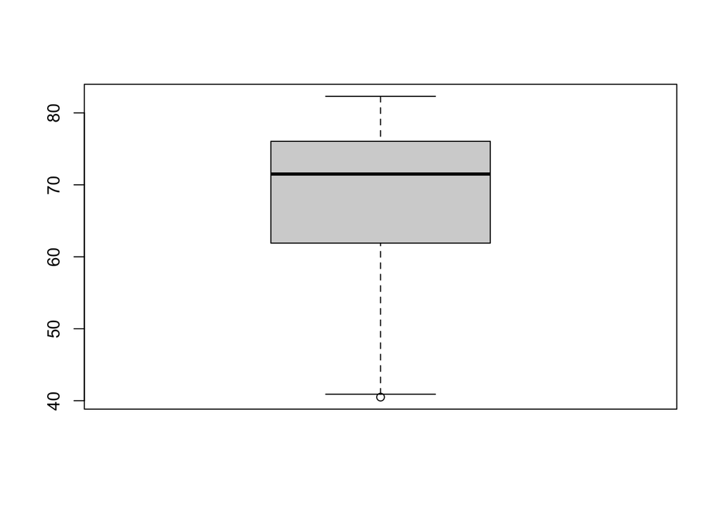

```r
boxplot(my_data$LifeExpectancy)
```

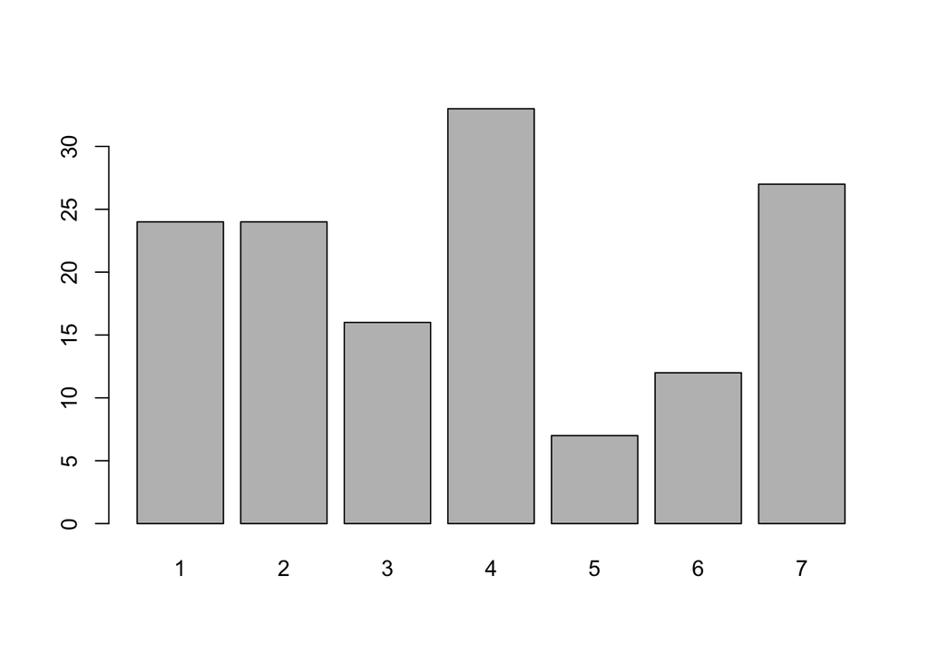

```r
tab <- table(my_data$Region)
barplot(tab)
```

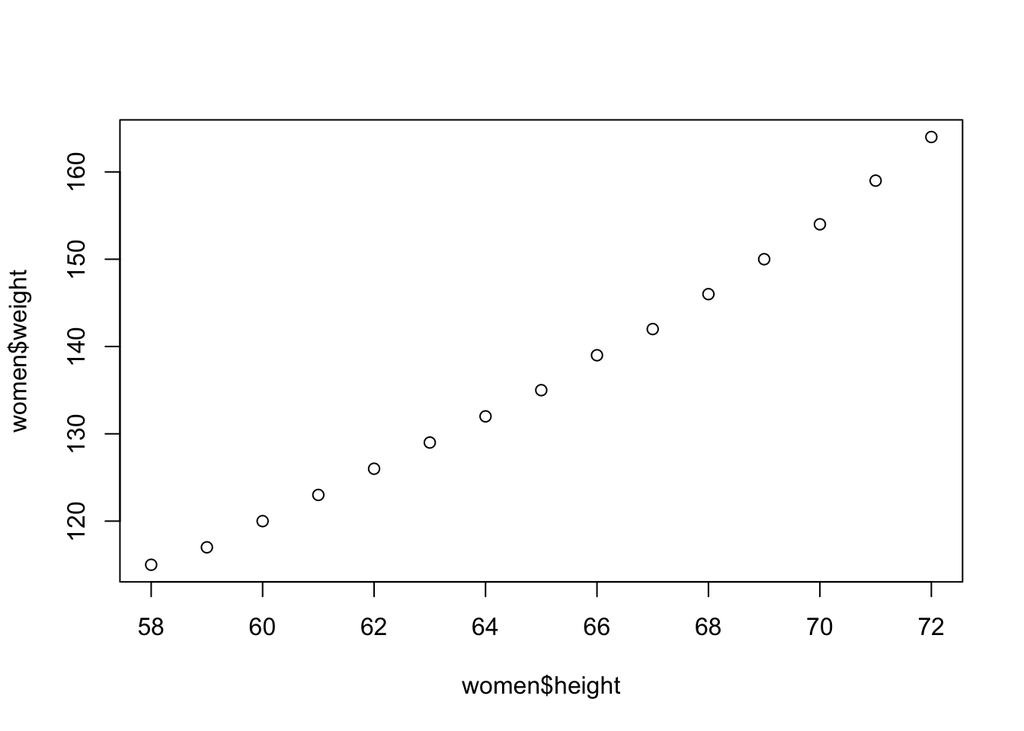

```r
plot(x=women$height, women$weight)
```

#**Question 11 P1**

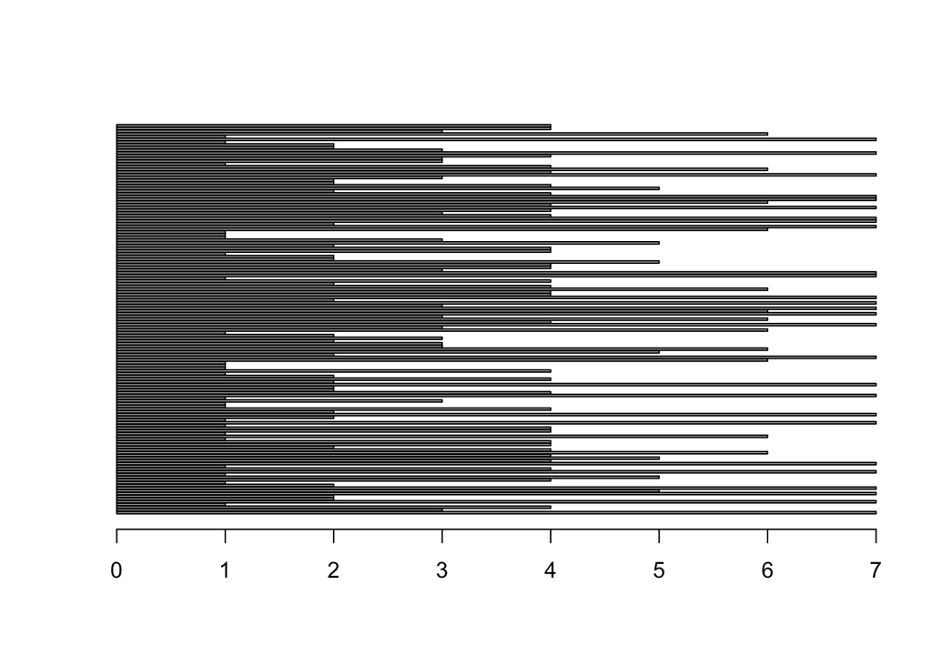

```r
?barplot
barplot(my_data$Region, horiz = TRUE)
```

#**Question 11 P2**

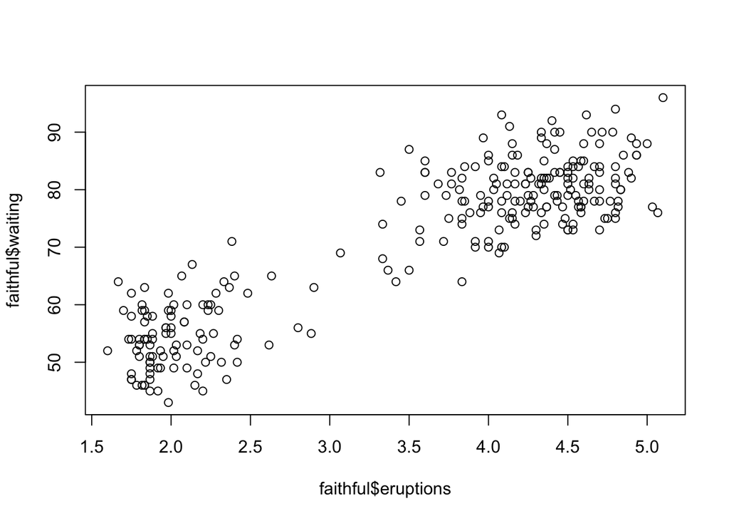

```r
?faithful
plot(x=faithful$eruptions, faithful$waiting)
```

It seems as though most of the eruptions either happen after around 1 or 2 minutes, or after 4 or 5 minutes, with the 2.5 to 3.5 minute mark being less frequent. Furthermore, the waiting time to the next eruption increases as the eruption time increases as well.

```r
mix_vec <- c(1, 2, 3, "a", "b", "c")
class(mix_vec)
```

```
## [1] "character"
```

```r
mix_vec <- c(TRUE, FALSE, 1, 2)
mix_vec
```

```
## [1] 1 0 1 2
```

```r
class(mix_vec)
```

```
## [1] "numeric"
```

```r
mix_vec <- c(TRUE, FALSE, "a")
mix_vec
```

```
## [1] "TRUE"  "FALSE" "a"
```

```r
vec <- c("1", "2", "3")
as.numeric(vec)
```

```
## [1] 1 2 3
```

```r
mix_vec <- c("1", "2", "3", "a")
as.numeric(mix_vec)
```

```
## [1]  1  2  3 NA
```

```r
?as.logical

v <- c(T, T, F)

v_num <- as.numeric(v)
v_char <- as.character(v_num)
v_logical <- as.logical(v_num)

v_logical
```

```
## [1]  TRUE  TRUE FALSE
```

#**Question 12** as.character makes the “1,1,0” numbers from v_num into characters, but as.logical only regards “True” or “False” character vectors as valid and therefore produces a NA as output. Since numerical vectors are different and can be converted directly into “True” or “False’ logical vectors, as.logical works in this case.

```r
x <- c ("1","2","3","a")
x <- as.numeric(x)
is.na(x)
```

```
## [1] FALSE FALSE FALSE  TRUE
```

```r
!is.na(x)
```

```
## [1]  TRUE  TRUE  TRUE FALSE
```

```r
x[!is.na(x)]
```

```
## [1] 1 2 3
```

```r
sum(x)
```

```
## [1] NA
```

```r
mean(x)
```

```
## [1] NA
```

```r
sum(x, na.rm = TRUE)
```

```
## [1] 6
```

```r
mean(x, na.rm = TRUE)
```

```
## [1] 2
```

```r
median(my_data$GDPperCapita, na.rm = TRUE)
```

```
## [1] 6632
```

```r
subt <- subset(my_data, is.na(GDPperCapita))
subt$Country
```

```
## [1] "Iraq"   "Serbia"
```

#**Question 13** The median GDP per capita is 6632. Serbia and Iraq were removed since their GDP per capita wasn’t reported.

```r
x1 <- c("Dec", "Apr", "Jan", "Mar")
x2 <- c("Dec", "Apr", "Jam", "Mar")
sort(x1)
```

```
## [1] "Apr" "Dec" "Jan" "Mar"
```

```r
month_levels <- c("Jan","Feb", "Mar", "Apr", "May", "Jun",
  "Jul", "Aug", "Sep", "Oct", "Nov", "Dec")
y1 <- factor(x1, levels = month_levels)
y1
```

```
## [1] Dec Apr Jan Mar
## Levels: Jan Feb Mar Apr May Jun Jul Aug Sep Oct Nov Dec
```

```r
sort(y1)
```

```
## [1] Jan Mar Apr Dec
## Levels: Jan Feb Mar Apr May Jun Jul Aug Sep Oct Nov Dec
```

```r
y2 <- factor(x2, levels = month_levels)
y2
```

```
## [1] Dec  Apr  <NA> Mar
## Levels: Jan Feb Mar Apr May Jun Jul Aug Sep Oct Nov Dec
```

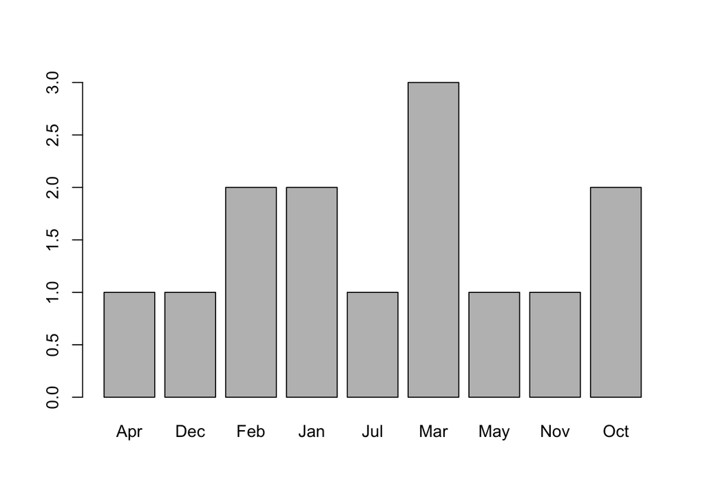

```r
?month.abb
x <- month.abb[c(1,3,2,5,12,11,10,10,3,4,1,3,2,7)]
barplot(table(x))
```

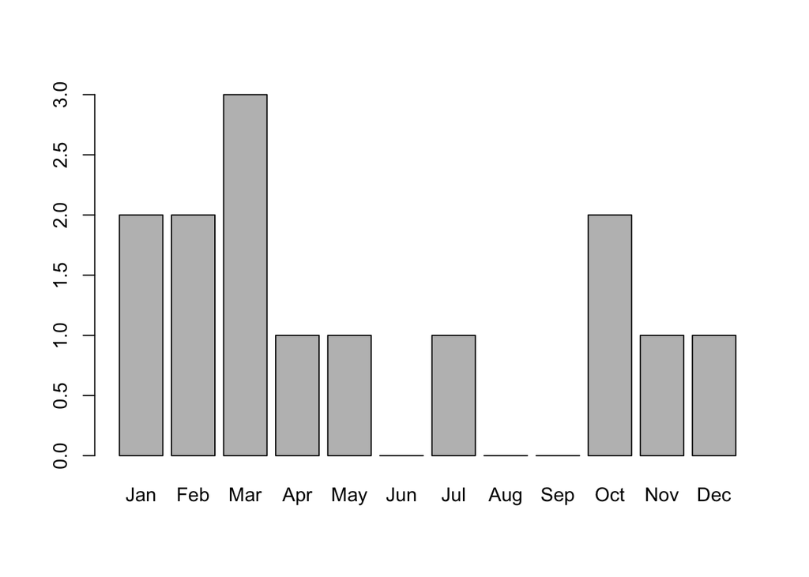

```r
y <- factor(x, levels = month_levels)
barplot(table(y))
```

```r
colleges <- read.csv("https://remiller1450.github.io/data/Colleges2019.csv")
```

#**Question 14**

```r
sub1 <- subset(colleges, Adm_Rate < 0.5 & Region == "Great Lakes")
mean(sub1$Salary10yr_median, na.rm = TRUE)
```

```
## [1] 47690.91
```

```r
sum(is.na(sub1$Salary10yr_median))
```

```
## [1] 3
```

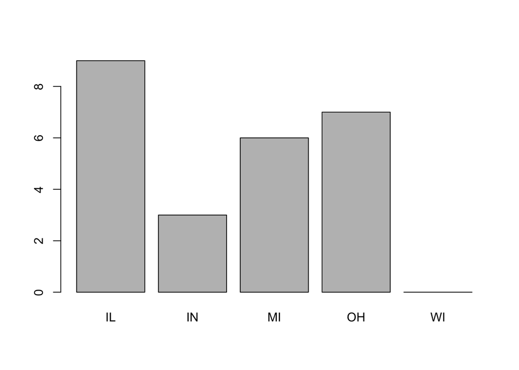

```r
state_levels <- c("IL", "IN", "MI", "OH", "WI")
z1 <- factor(sub1$State, levels = state_levels)
barplot(table(z1))
```